# Mechanism of action Dataset Exploratory Data Analysis(EDA)

```python
import pandas as pd
import numpy as np
import seaborn as sns
import matplotlib.pyplot as plt
from sklearn.preprocessing import LabelEncoder

import warnings
warnings.filterwarnings('ignore')
from sklearn.model_selection import train_test_split, cross_validate
from sklearn.preprocessing import StandardScaler, LabelEncoder
from sklearn.decomposition import PCA
from sklearn.linear_model import LogisticRegression
from sklearn.multiclass import OneVsRestClassifier
from sklearn.metrics import accuracy_score
from sklearn.pipeline import Pipeline
from sklearn.model_selection import GridSearchCV
from sklearn.pipeline import Pipeline
from sklearn.model_selection import GridSearchCV
from sklearn.metrics import f1_score, make_scorer
from sklearn.neighbors import KNeighborsClassifier
from sklearn import metrics
from keras.models import Sequential
from keras.layers import Dense
from keras.wrappers.scikit_learn import KerasClassifier
from keras.utils import np_utils
from sklearn.metrics import log_loss
from sklearn import metrics
```

# READING DATA :

```python
# Reading  testdata datasets
test_data = pd.read_csv("test_features.csv")
test_data
```

|  | sig_id | cp_type | cp_time | cp_dose | g-0 | g-1 | g-2 | g-3 | g-4 | g-5 | ... | c-90 | c-91 | c-92 | c-93 | c-94 | c-95 | c-96 | c-97 | c-98 | c-99 |
| --- | --- | --- | --- | --- | --- | --- | --- | --- | --- | --- | --- | --- | --- | --- | --- | --- | --- | --- | --- | --- | --- |
| 0 | id_0004d9e33 | trt_cp | 24 | D1 | -0.5458 | 0.1306 | -0.5135 | 0.4408 | 1.5500 | -0.1644 | ... | 0.0981 | 0.7978 | -0.1430 | -0.2067 | -0.2303 | -0.1193 | 0.0210 | -0.0502 | 0.1510 | -0.7750 |
| 1 | id_001897cda | trt_cp | 72 | D1 | -0.1829 | 0.2320 | 1.2080 | -0.4522 | -0.3652 | -0.3319 | ... | -0.1190 | -0.1852 | -1.0310 | -1.3670 | -0.3690 | -0.5382 | 0.0359 | -0.4764 | -1.3810 | -0.7300 |
| 2 | id_002429b5b | ctl_vehicle | 24 | D1 | 0.1852 | -0.1404 | -0.3911 | 0.1310 | -1.4380 | 0.2455 | ... | -0.2261 | 0.3370 | -1.3840 | 0.8604 | -1.9530 | -1.0140 | 0.8662 | 1.0160 | 0.4924 | -0.1942 |
| 3 | id_00276f245 | trt_cp | 24 | D2 | 0.4828 | 0.1955 | 0.3825 | 0.4244 | -0.5855 | -1.2020 | ... | 0.1260 | 0.1570 | -0.1784 | -1.1200 | -0.4325 | -0.9005 | 0.8131 | -0.1305 | 0.5645 | -0.5809 |
| 4 | id_0027f1083 | trt_cp | 48 | D1 | -0.3979 | -1.2680 | 1.9130 | 0.2057 | -0.5864 | -0.0166 | ... | 0.4965 | 0.7578 | -0.1580 | 1.0510 | 0.5742 | 1.0900 | -0.2962 | -0.5313 | 0.9931 | 1.8380 |
| ... | ... | ... | ... | ... | ... | ... | ... | ... | ... | ... | ... | ... | ... | ... | ... | ... | ... | ... | ... | ... | ... |
| 3977 | id_ff7004b87 | trt_cp | 24 | D1 | 0.4571 | -0.5743 | 3.3930 | -0.6202 | 0.8557 | 1.6240 | ... | -1.1790 | -0.6422 | -0.4367 | 0.0159 | -0.6539 | -0.4791 | -1.2680 | -1.1280 | -0.4167 | -0.6600 |
| 3978 | id_ff925dd0d | trt_cp | 24 | D1 | -0.5885 | -0.2548 | 2.5850 | 0.3456 | 0.4401 | 0.3107 | ... | 0.0210 | 0.5780 | -0.5888 | 0.8057 | 0.9312 | 1.2730 | 0.2614 | -0.2790 | -0.0131 | -0.0934 |
| 3979 | id_ffb710450 | trt_cp | 72 | D1 | -0.3985 | -0.1554 | 0.2677 | -0.6813 | 0.0152 | 0.4791 | ... | 0.4418 | 0.9153 | -0.1862 | 0.4049 | 0.9568 | 0.4666 | 0.0461 | 0.5888 | -0.4205 | -0.1504 |
| 3980 | id_ffbb869f2 | trt_cp | 48 | D2 | -1.0960 | -1.7750 | -0.3977 | 1.0160 | -1.3350 | -0.2207 | ... | 0.3079 | -0.4473 | -0.8192 | 0.7785 | 0.3133 | 0.1286 | -0.2618 | 0.5074 | 0.7430 | -0.0484 |
| 3981 | id_ffd5800b6 | trt_cp | 72 | D1 | -0.5174 | 0.2953 | 0.3286 | -0.0428 | -0.0800 | 0.8702 | ... | 0.0363 | 0.1708 | 0.5939 | -0.0507 | 0.2811 | -0.4041 | -0.4948 | 0.0757 | -0.1356 | 0.5280 |

3982 rows × 876 columns

```python
# Reading  traindata datasets
train_data = pd.read_csv("train_features.csv")
train_data
```

|  | sig_id | cp_type | cp_time | cp_dose | g-0 | g-1 | g-2 | g-3 | g-4 | g-5 | ... | c-90 | c-91 | c-92 | c-93 | c-94 | c-95 | c-96 | c-97 | c-98 | c-99 |
| --- | --- | --- | --- | --- | --- | --- | --- | --- | --- | --- | --- | --- | --- | --- | --- | --- | --- | --- | --- | --- | --- |
| 0 | id_000644bb2 | trt_cp | 24 | D1 | 1.0620 | 0.5577 | -0.2479 | -0.6208 | -0.1944 | -1.0120 | ... | 0.2862 | 0.2584 | 0.8076 | 0.5523 | -0.1912 | 0.6584 | -0.3981 | 0.2139 | 0.3801 | 0.4176 |
| 1 | id_000779bfc | trt_cp | 72 | D1 | 0.0743 | 0.4087 | 0.2991 | 0.0604 | 1.0190 | 0.5207 | ... | -0.4265 | 0.7543 | 0.4708 | 0.0230 | 0.2957 | 0.4899 | 0.1522 | 0.1241 | 0.6077 | 0.7371 |
| 2 | id_000a6266a | trt_cp | 48 | D1 | 0.6280 | 0.5817 | 1.5540 | -0.0764 | -0.0323 | 1.2390 | ... | -0.7250 | -0.6297 | 0.6103 | 0.0223 | -1.3240 | -0.3174 | -0.6417 | -0.2187 | -1.4080 | 0.6931 |
| 3 | id_0015fd391 | trt_cp | 48 | D1 | -0.5138 | -0.2491 | -0.2656 | 0.5288 | 4.0620 | -0.8095 | ... | -2.0990 | -0.6441 | -5.6300 | -1.3780 | -0.8632 | -1.2880 | -1.6210 | -0.8784 | -0.3876 | -0.8154 |
| 4 | id_001626bd3 | trt_cp | 72 | D2 | -0.3254 | -0.4009 | 0.9700 | 0.6919 | 1.4180 | -0.8244 | ... | 0.0042 | 0.0048 | 0.6670 | 1.0690 | 0.5523 | -0.3031 | 0.1094 | 0.2885 | -0.3786 | 0.7125 |
| ... | ... | ... | ... | ... | ... | ... | ... | ... | ... | ... | ... | ... | ... | ... | ... | ... | ... | ... | ... | ... | ... |
| 23809 | id_fffb1ceed | trt_cp | 24 | D2 | 0.1394 | -0.0636 | -0.1112 | -0.5080 | -0.4713 | 0.7201 | ... | 0.1969 | 0.0262 | -0.8121 | 0.3434 | 0.5372 | -0.3246 | 0.0631 | 0.9171 | 0.5258 | 0.4680 |
| 23810 | id_fffb70c0c | trt_cp | 24 | D2 | -1.3260 | 0.3478 | -0.3743 | 0.9905 | -0.7178 | 0.6621 | ... | 0.4286 | 0.4426 | 0.0423 | -0.3195 | -0.8086 | -0.9798 | -0.2084 | -0.1224 | -0.2715 | 0.3689 |
| 23811 | id_fffc1c3f4 | ctl_vehicle | 48 | D2 | 0.3942 | 0.3756 | 0.3109 | -0.7389 | 0.5505 | -0.0159 | ... | 0.5409 | 0.3755 | 0.7343 | 0.2807 | 0.4116 | 0.6422 | 0.2256 | 0.7592 | 0.6656 | 0.3808 |
| 23812 | id_fffcb9e7c | trt_cp | 24 | D1 | 0.6660 | 0.2324 | 0.4392 | 0.2044 | 0.8531 | -0.0343 | ... | -0.1105 | 0.4258 | -0.2012 | 0.1506 | 1.5230 | 0.7101 | 0.1732 | 0.7015 | -0.6290 | 0.0740 |
| 23813 | id_ffffdd77b | trt_cp | 72 | D1 | -0.8598 | 1.0240 | -0.1361 | 0.7952 | -0.3611 | -3.6750 | ... | -3.3890 | -1.7450 | -6.6300 | -4.0950 | -7.3860 | -1.4160 | -3.5770 | -0.4775 | -2.1500 | -4.2520 |

23814 rows × 876 columns

```python
#Target variables
# Reading  targetdata datasets
target_data = pd.read_csv("train_targets_scored.csv")
target_data
```

|  | sig_id | 5-alpha_reductase_inhibitor | 11-beta-hsd1_inhibitor | acat_inhibitor | acetylcholine_receptor_agonist | acetylcholine_receptor_antagonist | acetylcholinesterase_inhibitor | adenosine_receptor_agonist | adenosine_receptor_antagonist | adenylyl_cyclase_activator | ... | tropomyosin_receptor_kinase_inhibitor | trpv_agonist | trpv_antagonist | tubulin_inhibitor | tyrosine_kinase_inhibitor | ubiquitin_specific_protease_inhibitor | vegfr_inhibitor | vitamin_b | vitamin_d_receptor_agonist | wnt_inhibitor |
| --- | --- | --- | --- | --- | --- | --- | --- | --- | --- | --- | --- | --- | --- | --- | --- | --- | --- | --- | --- | --- | --- |
| 0 | id_000644bb2 | 0 | 0 | 0 | 0 | 0 | 0 | 0 | 0 | 0 | ... | 0 | 0 | 0 | 0 | 0 | 0 | 0 | 0 | 0 | 0 |
| 1 | id_000779bfc | 0 | 0 | 0 | 0 | 0 | 0 | 0 | 0 | 0 | ... | 0 | 0 | 0 | 0 | 0 | 0 | 0 | 0 | 0 | 0 |
| 2 | id_000a6266a | 0 | 0 | 0 | 0 | 0 | 0 | 0 | 0 | 0 | ... | 0 | 0 | 0 | 0 | 0 | 0 | 0 | 0 | 0 | 0 |
| 3 | id_0015fd391 | 0 | 0 | 0 | 0 | 0 | 0 | 0 | 0 | 0 | ... | 0 | 0 | 0 | 0 | 0 | 0 | 0 | 0 | 0 | 0 |
| 4 | id_001626bd3 | 0 | 0 | 0 | 0 | 0 | 0 | 0 | 0 | 0 | ... | 0 | 0 | 0 | 0 | 0 | 0 | 0 | 0 | 0 | 0 |
| ... | ... | ... | ... | ... | ... | ... | ... | ... | ... | ... | ... | ... | ... | ... | ... | ... | ... | ... | ... | ... | ... |
| 23809 | id_fffb1ceed | 0 | 0 | 0 | 0 | 0 | 0 | 0 | 0 | 0 | ... | 0 | 0 | 0 | 0 | 0 | 0 | 0 | 0 | 0 | 0 |
| 23810 | id_fffb70c0c | 0 | 0 | 0 | 0 | 0 | 0 | 0 | 0 | 0 | ... | 0 | 0 | 0 | 0 | 0 | 0 | 0 | 0 | 0 | 0 |
| 23811 | id_fffc1c3f4 | 0 | 0 | 0 | 0 | 0 | 0 | 0 | 0 | 0 | ... | 0 | 0 | 0 | 0 | 0 | 0 | 0 | 0 | 0 | 0 |
| 23812 | id_fffcb9e7c | 0 | 0 | 0 | 0 | 0 | 0 | 0 | 0 | 0 | ... | 0 | 0 | 0 | 0 | 0 | 0 | 0 | 0 | 0 | 0 |
| 23813 | id_ffffdd77b | 0 | 0 | 0 | 0 | 0 | 0 | 0 | 0 | 0 | ... | 0 | 0 | 0 | 0 | 0 | 0 | 0 | 0 | 0 | 0 |

23814 rows × 207 columns

# EXPLORATORY DATA ANALYSIS :

Features: sig_id - It is the drug ID for each drug

cp_type - Represents two categories, trt_cp is the one which has mechanism of action and ctl_vehicle is simply placebo and has no mechanism of action

cp_time - Represents three categories of duration of treatment i.e 24, 48, 72 hours.

cp_dose - Represents two categories ie High dose and low dose

g - Signifies gene expression data

c - Signifies cell viablity data

```python
#Exploratory data analysis
train_data.shape
```

```
(23814, 876)
```

```python
train_data.describe()
```

|  | cp_time | g-0 | g-1 | g-2 | g-3 | g-4 | g-5 | g-6 | g-7 | g-8 | ... | c-90 | c-91 | c-92 | c-93 | c-94 | c-95 | c-96 | c-97 | c-98 | c-99 |
| --- | --- | --- | --- | --- | --- | --- | --- | --- | --- | --- | --- | --- | --- | --- | --- | --- | --- | --- | --- | --- | --- |
| count | 23814.000000 | 23814.000000 | 23814.000000 | 23814.000000 | 23814.000000 | 23814.000000 | 23814.000000 | 23814.000000 | 23814.000000 | 23814.000000 | ... | 23814.000000 | 23814.000000 | 23814.000000 | 23814.000000 | 23814.000000 | 23814.000000 | 23814.000000 | 23814.000000 | 23814.000000 | 23814.000000 |
| mean | 48.020156 | 0.248366 | -0.095684 | 0.152253 | 0.081971 | 0.057347 | -0.138836 | 0.035961 | -0.202651 | -0.190083 | ... | -0.469244 | -0.461411 | -0.513256 | -0.500142 | -0.507093 | -0.353726 | -0.463485 | -0.378241 | -0.470252 | -0.301505 |
| std | 19.402807 | 1.393399 | 0.812363 | 1.035731 | 0.950012 | 1.032091 | 1.179388 | 0.882395 | 1.125494 | 1.749885 | ... | 2.000488 | 2.042475 | 2.001714 | 2.107105 | 2.159589 | 1.629291 | 2.059725 | 1.703615 | 1.834828 | 1.407918 |
| min | 24.000000 | -5.513000 | -5.737000 | -9.104000 | -5.998000 | -6.369000 | -10.000000 | -10.000000 | -10.000000 | -10.000000 | ... | -10.000000 | -10.000000 | -10.000000 | -10.000000 | -10.000000 | -10.000000 | -10.000000 | -10.000000 | -10.000000 | -10.000000 |
| 25% | 24.000000 | -0.473075 | -0.562200 | -0.437750 | -0.429575 | -0.470925 | -0.602225 | -0.493900 | -0.525175 | -0.511675 | ... | -0.566175 | -0.565975 | -0.589975 | -0.568700 | -0.563775 | -0.567975 | -0.552575 | -0.561000 | -0.592600 | -0.562900 |
| 50% | 48.000000 | -0.008850 | -0.046600 | 0.075200 | 0.008050 | -0.026900 | -0.015650 | -0.000650 | -0.017900 | 0.010000 | ... | -0.009900 | 0.003250 | -0.009100 | -0.013750 | -0.003300 | -0.010250 | -0.001250 | -0.006800 | 0.014000 | -0.019500 |
| 75% | 72.000000 | 0.525700 | 0.403075 | 0.663925 | 0.463400 | 0.465375 | 0.510425 | 0.528725 | 0.411900 | 0.549225 | ... | 0.457750 | 0.461500 | 0.445675 | 0.452900 | 0.470900 | 0.444750 | 0.465225 | 0.446400 | 0.461275 | 0.438650 |
| max | 72.000000 | 10.000000 | 5.039000 | 8.257000 | 10.000000 | 10.000000 | 7.282000 | 7.333000 | 5.473000 | 8.887000 | ... | 4.069000 | 3.960000 | 3.927000 | 3.596000 | 3.747000 | 2.814000 | 3.505000 | 2.924000 | 3.111000 | 3.805000 |

8 rows × 873 columns

```python
test_data.shape
```

```
(3982, 876)
```

```python
test_data.describe()
```

|  | cp_time | g-0 | g-1 | g-2 | g-3 | g-4 | g-5 | g-6 | g-7 | g-8 | ... | c-90 | c-91 | c-92 | c-93 | c-94 | c-95 | c-96 | c-97 | c-98 | c-99 |
| --- | --- | --- | --- | --- | --- | --- | --- | --- | --- | --- | --- | --- | --- | --- | --- | --- | --- | --- | --- | --- | --- |
| count | 3982.000000 | 3982.000000 | 3982.000000 | 3982.000000 | 3982.000000 | 3982.000000 | 3982.000000 | 3982.000000 | 3982.000000 | 3982.000000 | ... | 3982.000000 | 3982.000000 | 3982.000000 | 3982.000000 | 3982.000000 | 3982.000000 | 3982.000000 | 3982.000000 | 3982.000000 | 3982.000000 |
| mean | 48.030136 | 0.197471 | -0.063233 | 0.137516 | 0.049622 | 0.052434 | -0.147852 | 0.010424 | -0.166886 | -0.168069 | ... | -0.429980 | -0.413215 | -0.475762 | -0.462484 | -0.479196 | -0.346450 | -0.423905 | -0.316387 | -0.404859 | -0.269792 |
| std | 19.414155 | 1.373476 | 0.800573 | 1.066475 | 0.949972 | 0.994018 | 1.204934 | 0.859452 | 1.088335 | 1.666240 | ... | 2.013142 | 1.995433 | 1.963440 | 2.128477 | 2.149705 | 1.645669 | 2.086895 | 1.655524 | 1.790883 | 1.355936 |
| min | 24.000000 | -5.321000 | -4.142000 | -6.996000 | -3.765000 | -6.312000 | -8.717000 | -6.037000 | -8.833000 | -10.000000 | ... | -10.000000 | -10.000000 | -10.000000 | -10.000000 | -10.000000 | -10.000000 | -10.000000 | -10.000000 | -10.000000 | -10.000000 |
| 25% | 24.000000 | -0.502725 | -0.552975 | -0.431800 | -0.465350 | -0.445750 | -0.576000 | -0.521325 | -0.477400 | -0.526925 | ... | -0.527725 | -0.521850 | -0.539375 | -0.540450 | -0.548175 | -0.561525 | -0.497050 | -0.521125 | -0.531075 | -0.541950 |
| 50% | 48.000000 | -0.060700 | -0.027500 | 0.073400 | -0.036450 | -0.047800 | -0.012500 | -0.009200 | 0.002150 | -0.002900 | ... | 0.010050 | 0.010900 | 0.006550 | 0.017500 | 0.013450 | -0.020000 | 0.043800 | 0.020450 | 0.030750 | -0.006250 |
| 75% | 72.000000 | 0.454650 | 0.429950 | 0.641125 | 0.423150 | 0.436050 | 0.498950 | 0.495975 | 0.422500 | 0.518050 | ... | 0.478900 | 0.479625 | 0.442550 | 0.473300 | 0.487825 | 0.454400 | 0.501050 | 0.478925 | 0.487000 | 0.422800 |
| max | 72.000000 | 10.000000 | 4.536000 | 8.227000 | 10.000000 | 7.615000 | 6.356000 | 6.190000 | 2.995000 | 8.007000 | ... | 4.936000 | 5.300000 | 3.268000 | 4.087000 | 5.290000 | 5.053000 | 5.276000 | 3.074000 | 3.859000 | 4.149000 |

8 rows × 873 columns

```python
target_data.shape
```

```
(23814, 207)
```

```python
target_data.describe()
```

|  | 5-alpha_reductase_inhibitor | 11-beta-hsd1_inhibitor | acat_inhibitor | acetylcholine_receptor_agonist | acetylcholine_receptor_antagonist | acetylcholinesterase_inhibitor | adenosine_receptor_agonist | adenosine_receptor_antagonist | adenylyl_cyclase_activator | adrenergic_receptor_agonist | ... | tropomyosin_receptor_kinase_inhibitor | trpv_agonist | trpv_antagonist | tubulin_inhibitor | tyrosine_kinase_inhibitor | ubiquitin_specific_protease_inhibitor | vegfr_inhibitor | vitamin_b | vitamin_d_receptor_agonist | wnt_inhibitor |
| --- | --- | --- | --- | --- | --- | --- | --- | --- | --- | --- | --- | --- | --- | --- | --- | --- | --- | --- | --- | --- | --- |
| count | 23814.000000 | 23814.000000 | 23814.000000 | 23814.000000 | 23814.000000 | 23814.000000 | 23814.000000 | 23814.000000 | 23814.000000 | 23814.000000 | ... | 23814.000000 | 23814.000000 | 23814.000000 | 23814.000000 | 23814.000000 | 23814.000000 | 23814.000000 | 23814.000000 | 23814.000000 | 23814.000000 |
| mean | 0.000714 | 0.000756 | 0.001008 | 0.007979 | 0.012640 | 0.003065 | 0.002268 | 0.004031 | 0.000504 | 0.011338 | ... | 0.000252 | 0.001050 | 0.002016 | 0.013270 | 0.003065 | 0.000252 | 0.007139 | 0.001092 | 0.001638 | 0.001260 |
| std | 0.026709 | 0.027483 | 0.031731 | 0.088967 | 0.111716 | 0.055283 | 0.047566 | 0.063365 | 0.022443 | 0.105876 | ... | 0.015871 | 0.032384 | 0.044851 | 0.114429 | 0.055283 | 0.015871 | 0.084190 | 0.033025 | 0.040436 | 0.035472 |
| min | 0.000000 | 0.000000 | 0.000000 | 0.000000 | 0.000000 | 0.000000 | 0.000000 | 0.000000 | 0.000000 | 0.000000 | ... | 0.000000 | 0.000000 | 0.000000 | 0.000000 | 0.000000 | 0.000000 | 0.000000 | 0.000000 | 0.000000 | 0.000000 |
| 25% | 0.000000 | 0.000000 | 0.000000 | 0.000000 | 0.000000 | 0.000000 | 0.000000 | 0.000000 | 0.000000 | 0.000000 | ... | 0.000000 | 0.000000 | 0.000000 | 0.000000 | 0.000000 | 0.000000 | 0.000000 | 0.000000 | 0.000000 | 0.000000 |
| 50% | 0.000000 | 0.000000 | 0.000000 | 0.000000 | 0.000000 | 0.000000 | 0.000000 | 0.000000 | 0.000000 | 0.000000 | ... | 0.000000 | 0.000000 | 0.000000 | 0.000000 | 0.000000 | 0.000000 | 0.000000 | 0.000000 | 0.000000 | 0.000000 |
| 75% | 0.000000 | 0.000000 | 0.000000 | 0.000000 | 0.000000 | 0.000000 | 0.000000 | 0.000000 | 0.000000 | 0.000000 | ... | 0.000000 | 0.000000 | 0.000000 | 0.000000 | 0.000000 | 0.000000 | 0.000000 | 0.000000 | 0.000000 | 0.000000 |
| max | 1.000000 | 1.000000 | 1.000000 | 1.000000 | 1.000000 | 1.000000 | 1.000000 | 1.000000 | 1.000000 | 1.000000 | ... | 1.000000 | 1.000000 | 1.000000 | 1.000000 | 1.000000 | 1.000000 | 1.000000 | 1.000000 | 1.000000 | 1.000000 |

8 rows × 206 columns

```python
# Missing values in both test and train data

missing_value_train =print(train_data.isnull().sum().sum())
missing_value_test = print(test_data.isnull().sum().sum())
missing_value_target = print(target_data.isnull().sum().sum())
```

```
0
0
0
```

There are no missing values in the dataset.

# Train features:

There are three categorical features in train data i.e cp_type, cp_time, cp_dose

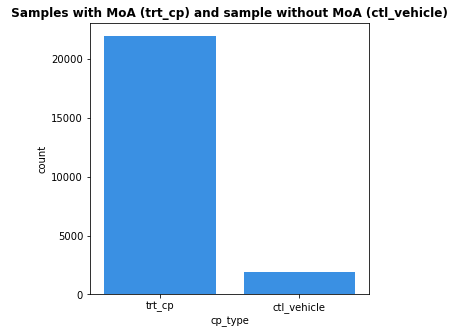

```python
# cp_type
train_data.cp_type.astype("category")
plt.figure(figsize=(5,5))
sns.set_palette("tab20")
sns.countplot(train_data['cp_type'], color='dodgerblue')
plt.title(" Samples with MoA (trt_cp) and sample without MoA (ctl_vehicle) ", fontsize=12, weight='bold')
plt.show()
```

As we can see that cp_type is imbalanced whith high number of trt*cp, which is expected since it has MoA.As we know ctl* vehcicle has no MoA(placebo), so it will of no use to us and we will discard it from our dataset for our further analysis

```python
# remove ctl_vehicle from train data
train_data= train_data.drop(train_data[train_data.cp_type == "ctl_vehicle"].index)
train_data
```

|  | sig_id | cp_type | cp_time | cp_dose | g-0 | g-1 | g-2 | g-3 | g-4 | g-5 | ... | c-90 | c-91 | c-92 | c-93 | c-94 | c-95 | c-96 | c-97 | c-98 | c-99 |
| --- | --- | --- | --- | --- | --- | --- | --- | --- | --- | --- | --- | --- | --- | --- | --- | --- | --- | --- | --- | --- | --- |
| 0 | id_000644bb2 | trt_cp | 24 | D1 | 1.0620 | 0.5577 | -0.2479 | -0.6208 | -0.1944 | -1.0120 | ... | 0.2862 | 0.2584 | 0.8076 | 0.5523 | -0.1912 | 0.6584 | -0.3981 | 0.2139 | 0.3801 | 0.4176 |
| 1 | id_000779bfc | trt_cp | 72 | D1 | 0.0743 | 0.4087 | 0.2991 | 0.0604 | 1.0190 | 0.5207 | ... | -0.4265 | 0.7543 | 0.4708 | 0.0230 | 0.2957 | 0.4899 | 0.1522 | 0.1241 | 0.6077 | 0.7371 |
| 2 | id_000a6266a | trt_cp | 48 | D1 | 0.6280 | 0.5817 | 1.5540 | -0.0764 | -0.0323 | 1.2390 | ... | -0.7250 | -0.6297 | 0.6103 | 0.0223 | -1.3240 | -0.3174 | -0.6417 | -0.2187 | -1.4080 | 0.6931 |
| 3 | id_0015fd391 | trt_cp | 48 | D1 | -0.5138 | -0.2491 | -0.2656 | 0.5288 | 4.0620 | -0.8095 | ... | -2.0990 | -0.6441 | -5.6300 | -1.3780 | -0.8632 | -1.2880 | -1.6210 | -0.8784 | -0.3876 | -0.8154 |
| 4 | id_001626bd3 | trt_cp | 72 | D2 | -0.3254 | -0.4009 | 0.9700 | 0.6919 | 1.4180 | -0.8244 | ... | 0.0042 | 0.0048 | 0.6670 | 1.0690 | 0.5523 | -0.3031 | 0.1094 | 0.2885 | -0.3786 | 0.7125 |
| ... | ... | ... | ... | ... | ... | ... | ... | ... | ... | ... | ... | ... | ... | ... | ... | ... | ... | ... | ... | ... | ... |
| 23808 | id_fff8c2444 | trt_cp | 72 | D1 | 0.1608 | -1.0500 | 0.2551 | -0.2239 | -0.2431 | 0.4256 | ... | 0.0789 | 0.3538 | 0.0558 | 0.3377 | -0.4753 | -0.2504 | -0.7415 | 0.8413 | -0.4259 | 0.2434 |
| 23809 | id_fffb1ceed | trt_cp | 24 | D2 | 0.1394 | -0.0636 | -0.1112 | -0.5080 | -0.4713 | 0.7201 | ... | 0.1969 | 0.0262 | -0.8121 | 0.3434 | 0.5372 | -0.3246 | 0.0631 | 0.9171 | 0.5258 | 0.4680 |
| 23810 | id_fffb70c0c | trt_cp | 24 | D2 | -1.3260 | 0.3478 | -0.3743 | 0.9905 | -0.7178 | 0.6621 | ... | 0.4286 | 0.4426 | 0.0423 | -0.3195 | -0.8086 | -0.9798 | -0.2084 | -0.1224 | -0.2715 | 0.3689 |
| 23812 | id_fffcb9e7c | trt_cp | 24 | D1 | 0.6660 | 0.2324 | 0.4392 | 0.2044 | 0.8531 | -0.0343 | ... | -0.1105 | 0.4258 | -0.2012 | 0.1506 | 1.5230 | 0.7101 | 0.1732 | 0.7015 | -0.6290 | 0.0740 |
| 23813 | id_ffffdd77b | trt_cp | 72 | D1 | -0.8598 | 1.0240 | -0.1361 | 0.7952 | -0.3611 | -3.6750 | ... | -3.3890 | -1.7450 | -6.6300 | -4.0950 | -7.3860 | -1.4160 | -3.5770 | -0.4775 | -2.1500 | -4.2520 |

21948 rows × 876 columns

[figure not shown]

```python
#cp_time
train_data.cp_time.astype("category")
plt.figure(figsize=(5,5))
sns.set_palette("tab20")
sns.countplot(train_data['cp_time'], color='palegreen')
plt.title(" Duration of treatment ", fontsize=12, weight='bold')
plt.show()

# Treatment durations are pretty balanced for our dataset
```

[figure not shown]

```python
#cp_dose
train_data.cp_dose.astype("category")
plt.figure(figsize=(5,5))
sns.set_palette("tab20")
sns.countplot(train_data['cp_dose'], color='salmon')
plt.title("Dose type high or low ", fontsize=12, weight='bold')
plt.show()
#Dose type are pretty balanced and evenly distributed for our dataset
```